# Political Science 312 Homework 4

2025-02-18

# Due Date: May 2, 2024

### Control Variables from Existing Studies

Remember in Lab 1 that you found a set of existing studies on your research question or related topics. Start by going through those studies and building a table of all the control variables used in statistical models in those studies. Make each control variable a row and each study a column, and mark a cell with an X or check if the variable is included in that study.

How many variables show consensus and are included in every study? How many show disagreement? Can you make sense of why?

Do you agree that the variables that every, or almost every, study uses are good control variables? Why or why not?

Do you think some of the more controversial variables might be good control variables? Why or why not?

### Justify a Control Variable Strategy

If you are going to use a control variables approach to causal inference, you will need to be able to explain which control variables are needed and which are not. An economical way to make such an argument is a DAG (directed acyclic graph) diagram. Make such a diagram, showing the causal relationships you think are present among the important control variables in your research question of interest.

In R, the best way create such a diagram is with daggity like the example below.

Explain your reasoning behind the variables you include and the links you specify, but also the the variables and links you leave out.

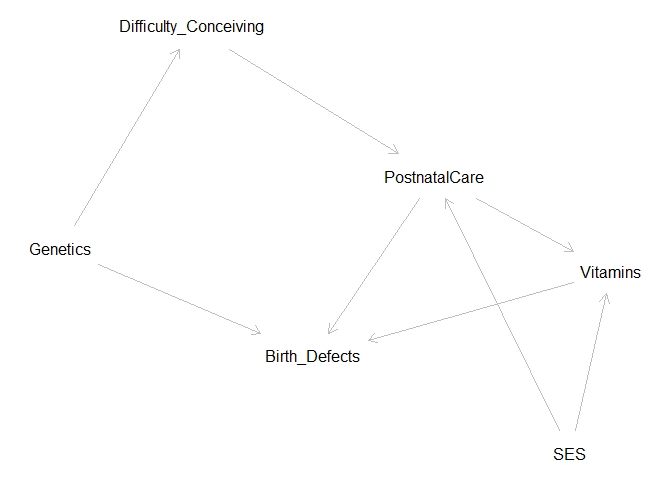

```r
library(dagitty)
dag_cand3 <- dagitty('dag {
                          Difficulty_Conceiving -> PostnatalCare
                          Genetics -> Birth_Defects
                          Genetics -> Difficulty_Conceiving
                          PostnatalCare -> Birth_Defects
                          PostnatalCare -> Vitamins
                          SES -> PostnatalCare
                          SES -> Vitamins
                          Vitamins -> Birth_Defects
                          }')
plot(dag_cand3)
```

### Possible Confounders

Using your DAG as well as your inventory from other people’s research, list the possible confounders in this relationship, i.e., variables that cause both the DV and the IV.

### Pathway Variables

Think of at least one variable that could be part of the causal pathway connecting your IV to your DV, and explain your reasoning. Could any of your possible confounders from the previous question also be pathway variables? Why or why not? Does this pose any possible problems to watch out for later on?